# final DM TD

2023-12-09

```r
library(tidyverse)
library(lubridate)
```

### Reading the data

```r
dt = read.csv("2019-Oct.csv")
head(dt)
```

```
##                event_time event_type product_id  category_id category_code
## 1 2019-10-01 00:00:00 UTC       cart    5773203 1.487580e+18
## 2 2019-10-01 00:00:03 UTC       cart    5773353 1.487580e+18
## 3 2019-10-01 00:00:07 UTC       cart    5881589 2.151191e+18
## 4 2019-10-01 00:00:07 UTC       cart    5723490 1.487580e+18
## 5 2019-10-01 00:00:15 UTC       cart    5881449 1.487580e+18
## 6 2019-10-01 00:00:16 UTC       cart    5857269 1.487580e+18
##    brand price   user_id                         user_session
## 1 runail  2.62 463240011 26dd6e6e-4dac-4778-8d2c-92e149dab885
## 2 runail  2.62 463240011 26dd6e6e-4dac-4778-8d2c-92e149dab885
## 3 lovely 13.48 429681830 49e8d843-adf3-428b-a2c3-fe8bc6a307c9
## 4 runail  2.62 463240011 26dd6e6e-4dac-4778-8d2c-92e149dab885
## 5 lovely  0.56 429681830 49e8d843-adf3-428b-a2c3-fe8bc6a307c9
## 6 runail  2.62 430174032 73dea1e7-664e-43f4-8b30-d32b9d5af04f
```

### Frequency tables of categorical variables

```r
table(dt$event_type)
```

```
##
##             cart         purchase remove_from_cart             view
##          1232385           245624           762110          1862164
```

```r
table(dt$category_code)
```

```
##
##                                                               accessories.bag
##                                4034806                                   5848
##               accessories.cosmetic_bag                          apparel.glove
##                                    642                                   7430
## appliances.environment.air_conditioner          appliances.environment.vacuum
##                                    161                                  27732
##        appliances.personal.hair_cutter                furniture.bathroom.bath
##                                    828                                   5018
##          furniture.living_room.cabinet            furniture.living_room.chair
##                                   6234                                    123
##                           sport.diving                    stationery.cartrige
##                                      2                                  13459
```

```r
table(dt$brand)
```

```
##
##                    airnails         almea        andrea        ardell
##       1659261         18956          1152           180          4593
##    art-visage         artex          aura     australis      balbcare
##         12157          4534           254            34          1030
##        barbie       batiste       beautix   beauty-free beautyblender
##            23           920         18795          5453           281
##    beauugreen        benovy       bergamo     bespecial       binacil
##           761           690           966           628           108
##       bioaqua    biofollica         biore         blise         blixz
##          6410           430           337            15           797
##       bluesky      bodipure       bodyton        bosnic     bpw.style
##         44308            10          3219            51        114192
##     browxenna         busch         candy        carmex           chi
##         13487            20          1574           516          1149
##           cnd        coifin       concept        consly        coocla
##         44257          1023         41295           573          1428
##        cosima    cosmoprofi         coxir   cristalinas        cruset
##           184         21544           624           796           401
##        cuccio        cutrin        de.lux      deoproce     depilflax
##             8           934         18680          1132          6380
##      dermacol        dermal       dessata         dizao         domix
##            20          3082             2          5186         34236
##        dorena    dr.gloderm      ecocraft        ecolab      egomania
##           274           637            62          1828           458
##    elizavecca        ellips        elskin   embryolisse          emil
##           781           978          1507            14          4496
##          enas        enigma         enjoy        entity           eos
##           721           966           326          6701           200
##       esquire         essie         estel      estelare        eunyul
##            19            21         64442          2330          2512
##         f.o.x         fancy     farmavita       farmona      farmstay
##         25390           485          4294          1826         10077
##         fedua        finish           fly        foamie     footlogix
##           215           411            96            91             3
##     freedecor   freshbubble        frozen        gehwol          gena
##         41655          1341           108          1151             2
##      glysolid      godefroy         grace       grattol        greymy
##           561           992           859        132130           234
##     happyfons      haruyama    helloganic         i-laq    igrobeauty
```

[output cut: 44 more lines]

```
##          4631            37          4196           120          9778
##         soleo      solomeya        sophin       staleks        strong
##          3141         10979          4911         20570         12049
##           sun         sunuv      supertan     swarovski     tannymaxx
##           153          8768           646          8364           392
##         tazol        tertio         thuya     tosowoong   treaclemoon
##           148          1969          4104            87           793
##         trind           uno      uralsoap        uskusi     veraclara
##          4239         48028            12         25544           318
##       vilenta        vl-gel         voesh         vosev        weaver
##          1410             3             4           853            48
##          yoko         ypsed          yu-r           zab        zeitun
##         20131           623           345            57          2690
##        zinger
##         27941
```

### Visualisation of frequency tables

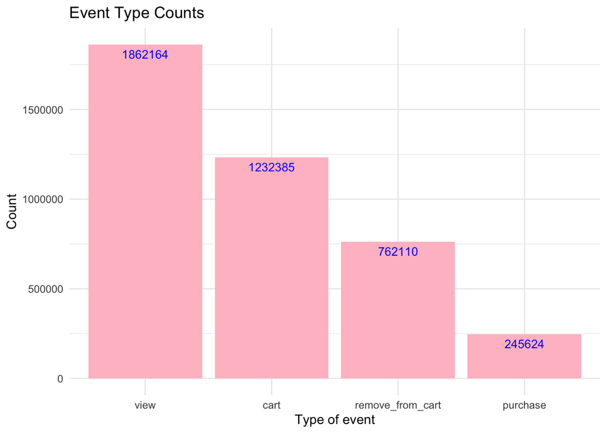

```r
count_data <- dt %>%
  group_by(event_type) %>%
  summarize(count = n()) %>%
  arrange(desc(count)) %>%
  mutate(event_type = factor(event_type, levels = event_type))

ggplot(data = count_data, aes(x = event_type, y = count)) +
  geom_bar(stat = "identity", fill = "pink") +
  labs(title = "Event Type Counts",
       x = "Type of event",
       y = "Count") +
  theme_minimal() + geom_text(aes(label=count), vjust=1.6, color="blue",
            position = position_dodge(0.9), size=3.5)
```

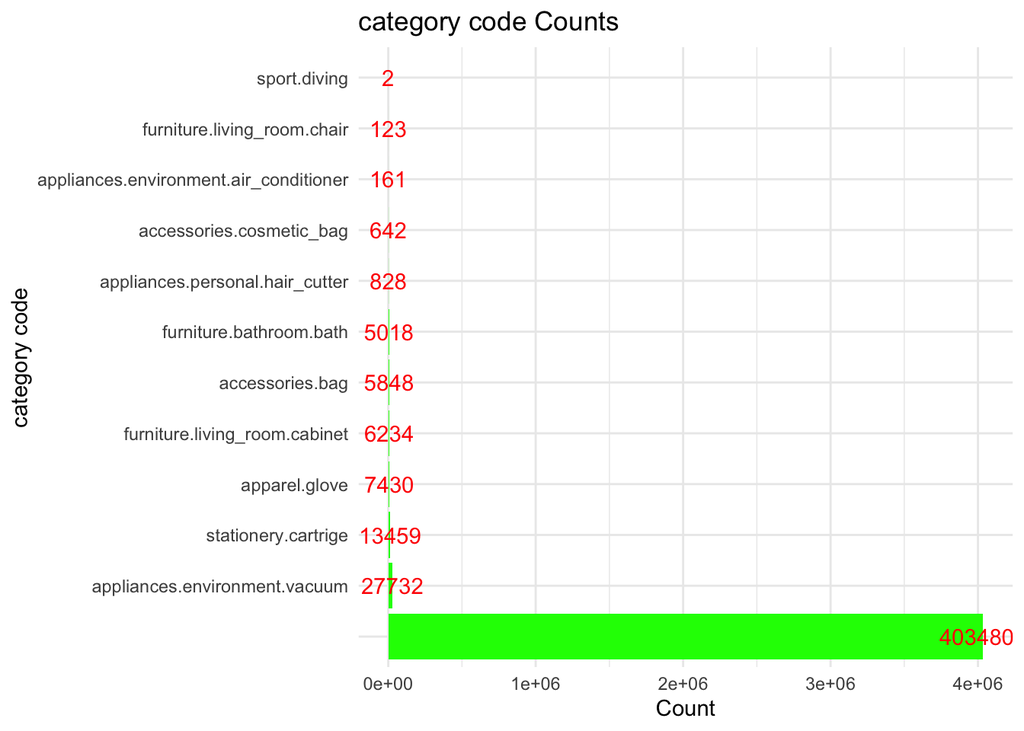

```r
count_data <- dt %>%
  group_by(category_code) %>%
  summarize(count = n()) %>%
  arrange(desc(count)) %>%
  mutate(category_code = factor(category_code, levels = category_code))

ggplot(data = count_data, aes(x = category_code, y = count)) +
  geom_bar(stat = "identity", fill = "green") +
  labs(title = "category code Counts",
       x = "category code",
       y = "Count") +
  theme_minimal() + geom_text(aes(label=count),color="red")+ coord_flip()
```

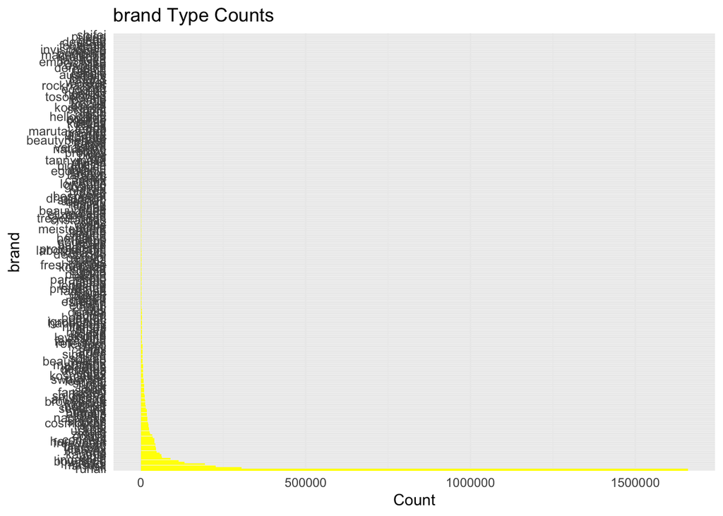

```r
count_data <- dt %>%
  group_by(brand) %>%
  summarize(count = n()) %>%
  arrange(desc(count)) %>%
  mutate(brand = factor(brand, levels = brand))

ggplot(data = count_data, aes(x = brand, y = count,)) +
  geom_bar(stat = "identity", fill = "yellow") +
  labs(title = "brand Type Counts",
       x = "brand",
       y = "Count") +
  theme_minimal() + coord_flip()
```

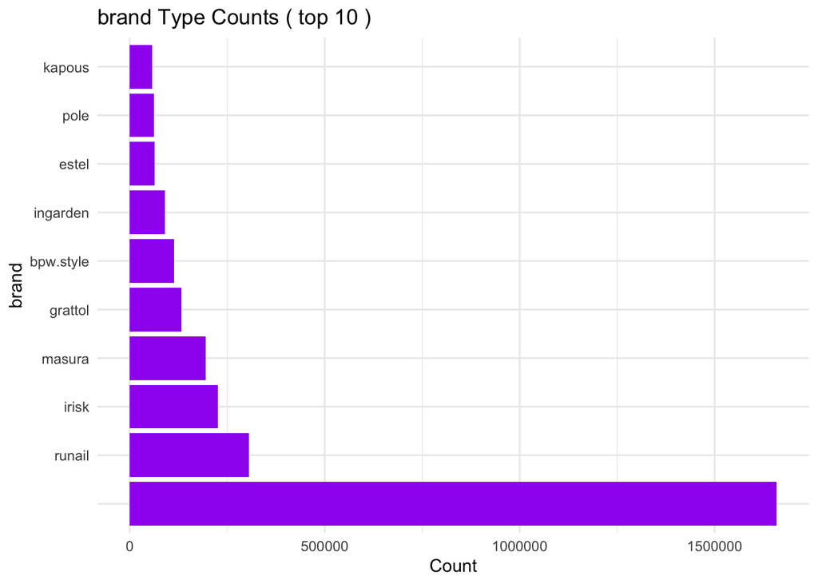

```r
count_data <- dt %>%
  group_by(brand) %>%
  summarize(count = n()) %>%
  arrange(desc(count)) %>%
  mutate(brand = factor(brand, levels = brand)) %>% head(10)

ggplot(data = count_data, aes(x = brand, y = count)) +
  geom_bar(stat = "identity", fill = "purple") +
  labs(title = "brand Type Counts ( top 10 )",
       x = "brand",
       y = "Count") +
  theme_minimal() + coord_flip()
```

### Price Distrivution

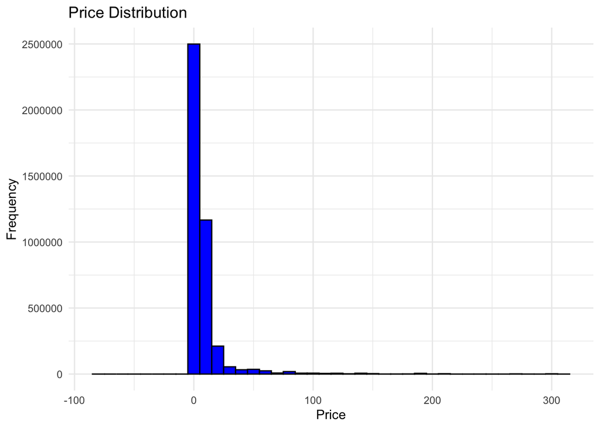

```r
ggplot(dt, aes(x = price)) +
  geom_histogram(binwidth = 10, fill = "blue", color = "black") +
  labs(title = "Price Distribution", x = "Price", y = "Frequency") +
  theme_minimal()
```

The distribution of price is rightly skewed

```r
dt$price <- ifelse(dt$price < 0, mean(dt$price), dt$price)
```

### Summary Statistics

```r
summary(dt)
```

```
##   event_time         event_type          product_id       category_id
##  Length:4102283     Length:4102283     Min.   :   3752   Min.   :1.488e+18
##  Class :character   Class :character   1st Qu.:5723489   1st Qu.:1.488e+18
##  Mode  :character   Mode  :character   Median :5809115   Median :1.488e+18
##                                        Mean   :5468464   Mean   :1.546e+18
##                                        3rd Qu.:5850322   3rd Qu.:1.488e+18
##                                        Max.   :5900470   Max.   :2.195e+18
##  category_code         brand               price            user_id
##  Length:4102283     Length:4102283     Min.   :  0.000   Min.   :  4103071
##  Class :character   Class :character   1st Qu.:  2.140   1st Qu.:469292064
##  Mode  :character   Mode  :character   Median :  4.110   Median :538969491
##                                        Mean   :  8.535   Mean   :501341626
##                                        3rd Qu.:  7.140   3rd Qu.:557502904
##                                        Max.   :307.600   Max.   :566280798
##  user_session
##  Length:4102283
##  Class :character
##  Mode  :character
##
##
##
```

### Data structure

```r
str(dt)
```

```
## 'data.frame':    4102283 obs. of  9 variables:
##  $ event_time   : chr  "2019-10-01 00:00:00 UTC" "2019-10-01 00:00:03 UTC" "2019-10-01 00:00:07 UTC" "2019-10-01 00:00:07 UTC" ...
##  $ event_type   : chr  "cart" "cart" "cart" "cart" ...
##  $ product_id   : int  5773203 5773353 5881589 5723490 5881449 5857269 5739055 5825598 5698989 5875317 ...
##  $ category_id  : num  1.49e+18 1.49e+18 2.15e+18 1.49e+18 1.49e+18 ...
##  $ category_code: chr  "" "" "" "" ...
##  $ brand        : chr  "runail" "runail" "lovely" "runail" ...
##  $ price        : num  2.62 2.62 13.48 2.62 0.56 ...
##  $ user_id      : int  463240011 463240011 429681830 463240011 429681830 430174032 377667011 467916806 385985999 474232307 ...
##  $ user_session : chr  "26dd6e6e-4dac-4778-8d2c-92e149dab885" "26dd6e6e-4dac-4778-8d2c-92e149dab885" "49e8d843-adf3-428b-a2c3-fe8bc6a307c9" "26dd6e6e-4dac-4778-8d2c-92e149dab885" ...
```

### inappropriate values

The variables category_code and brand have inappropriate values like “” which are empty. we will be segregating brand to 0 and 1 wth “” as 0 and rest as 1 . Similary for category_code we will be labelling as Unknown , appliances,accessories,furniture and stationery. it also has sport.diving label which we will add into unknown as it has only 2 values from the total data so create a dummy at the time of building a model wont make sense.

```r
dt$category_code[dt$category_code == ""] <- "unknown"

merge_categories <- function(category) {
  if (grepl("^furniture", category))
    return("furniture")

  if (grepl("^appliances", category))
    return("appliances")

  if (grepl("^accessories", category))
    return("accessories")

  if (grepl("^sport", category))
    return("unknown")

  return(category)
}

dt$category_code <- sapply(dt$category_code, merge_categories)

dt$brand = ifelse(dt$brand == "",0,1)
table(dt$brand)
```

```
##
##       0       1
## 1659261 2443022
```

### Oultier detection and removal

```r
Q1 <- quantile(dt$price, 0.25, na.rm = TRUE)
Q3 <- quantile(dt$price, 0.75, na.rm = TRUE)
IQR <- Q3 - Q1

lower_bound <- Q1 - 1.5 * IQR
upper_bound <- Q3 + 1.5 * IQR

outliers <- dt[dt$price < lower_bound | dt$price > upper_bound, ]

dt_no_outliers <- dt[dt$price >= lower_bound & dt$price <= upper_bound, ]
```

### Data structure after outlier removal

```r
str(dt_no_outliers)
```

```
## 'data.frame':    3663737 obs. of  9 variables:
##  $ event_time   : chr  "2019-10-01 00:00:00 UTC" "2019-10-01 00:00:03 UTC" "2019-10-01 00:00:07 UTC" "2019-10-01 00:00:07 UTC" ...
##  $ event_type   : chr  "cart" "cart" "cart" "cart" ...
##  $ product_id   : int  5773203 5773353 5881589 5723490 5881449 5857269 5739055 5825598 5698989 5875317 ...
##  $ category_id  : num  1.49e+18 1.49e+18 2.15e+18 1.49e+18 1.49e+18 ...
##  $ category_code: chr  "unknown" "unknown" "unknown" "unknown" ...
##  $ brand        : num  1 1 1 1 1 1 1 0 0 0 ...
##  $ price        : num  2.62 2.62 13.48 2.62 0.56 ...
##  $ user_id      : int  463240011 463240011 429681830 463240011 429681830 430174032 377667011 467916806 385985999 474232307 ...
##  $ user_session : chr  "26dd6e6e-4dac-4778-8d2c-92e149dab885" "26dd6e6e-4dac-4778-8d2c-92e149dab885" "49e8d843-adf3-428b-a2c3-fe8bc6a307c9" "26dd6e6e-4dac-4778-8d2c-92e149dab885" ...
```

### Visualisation after outlier removal

### Distribution of Price

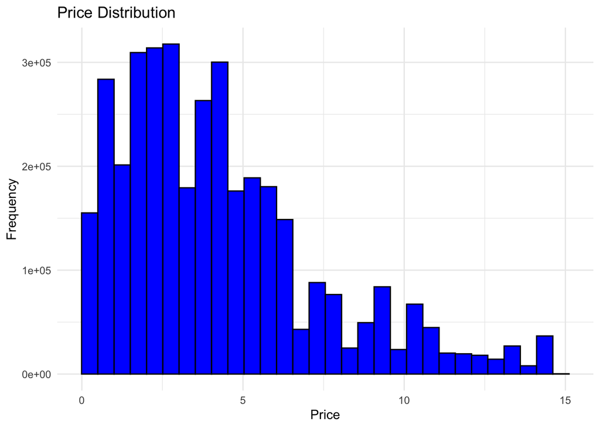

```r
ggplot(dt_no_outliers, aes(x = price)) +
  geom_histogram(fill = "blue", color = "black", boundary = 1) +
  labs(title = "Price Distribution", x = "Price", y = "Frequency") +
  theme_minimal()
```

### Event type count visualisation after outlier removal

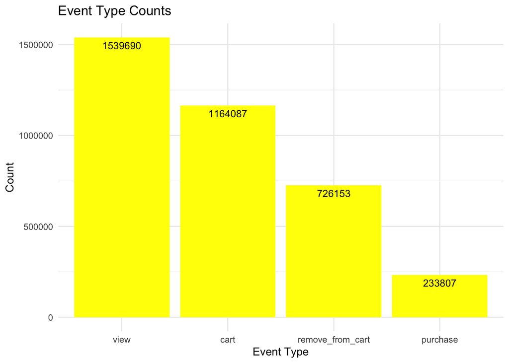

```r
count_data <- dt_no_outliers %>%
  group_by(event_type) %>%
  summarize(count = n()) %>%
  arrange(desc(count)) %>%
  mutate(event_type = factor(event_type, levels = event_type))

ggplot(data = count_data, aes(x = event_type, y = count)) +
  geom_bar(stat = "identity", fill = "yellow") +
  labs(title = "Event Type Counts",
       x = "Event Type",
       y = "Count") +
  theme_minimal() + geom_text(aes(label=count), vjust=1.6, color="black",
            position = position_dodge(0.9), size=3.5)
```

### Brand type count visualisation after outlier removal

#### 1 = Top known brands , 0 = local / unknown brands

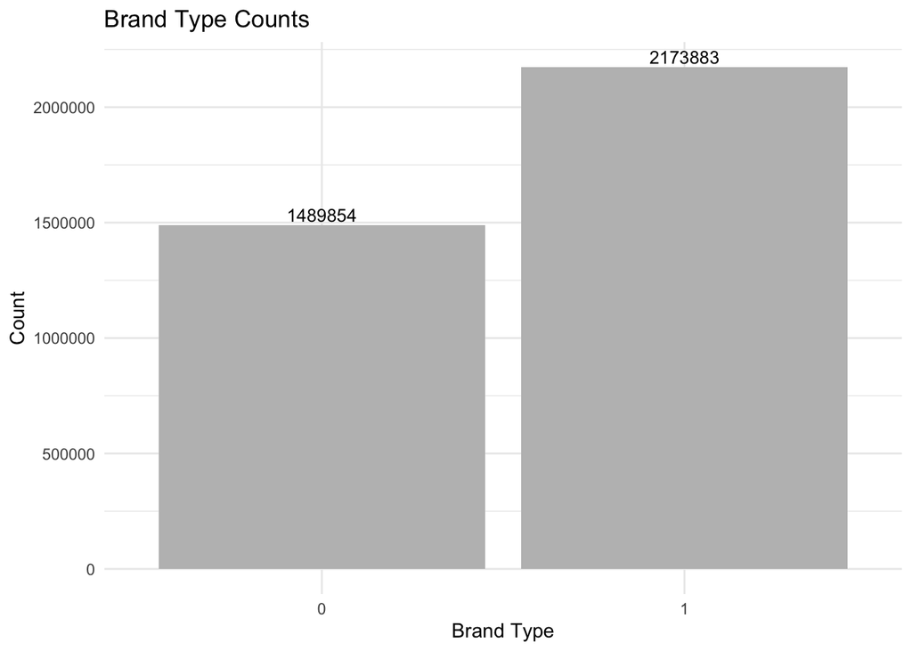

```r
library(dplyr)
library(ggplot2)
library(forcats)

count_data <- dt_no_outliers %>%
  group_by(brand) %>%
  summarize(count = n(), .groups = 'drop') %>%
  mutate(brand = as.factor(brand),  # Convert brand to a factor
         brand = fct_reorder(brand, count))  # Reorder brand by count

ggplot(data = count_data, aes(x = brand, y = count)) +
  geom_bar(stat = "identity", fill = "grey") +
  labs(title = "Brand Type Counts",
       x = "Brand Type",
       y = "Count") +
  theme_minimal() +
  geom_text(aes(label = count), vjust = -0.3, color = "black", size = 3.5)
```

### Category code type count visualisation after outlier removal

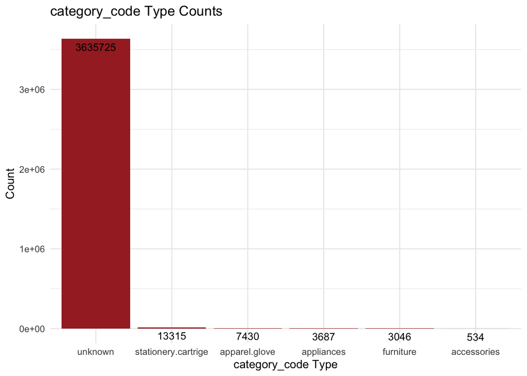

```r
count_data <- dt_no_outliers %>%
  group_by(category_code) %>%
  summarize(count = n()) %>%
  arrange(desc(count)) %>%
  mutate(category_code = factor(category_code, levels = category_code))

ggplot(data = count_data, aes(x = category_code, y = count)) +
  geom_bar(stat = "identity", fill = "brown") +
  labs(title = "category_code Type Counts",
       x = "category_code Type",
       y = "Count") +
  theme_minimal() + geom_text(aes(label=count), vjust=1.6, color="black",
            position = position_dodge(0.9), size=3.5)
```

### Creation of new variables for EDA

```r
dt_no_outliers$event_time = ymd_hms(dt_no_outliers$event_time)
dt_no_outliers$day_of_week <- weekdays(dt_no_outliers$event_time)
dt_no_outliers$hour <- hour(dt_no_outliers$event_time)
dt_no_outliers$time_of_day <- cut(
  dt_no_outliers$hour,
  breaks = c(0, 12, 18, 24),
  labels = c("morning", "afternoon", "evening"),
  include.lowest = TRUE,
  right = FALSE
)
```

### Dummy variables

```r
library(fastDummies)
dt = dummy_cols(dt_no_outliers, select_columns = c("event_type","category_code"),remove_selected_columns = TRUE)
```

So the dependent variable is ‘event_type_cart’

### Exploratory data analysis

### Dealing with event types with time of the day

```r
dt %>% group_by(event_type_cart,time_of_day) %>% summarise(n=n())
```

```
## # A tibble: 6 × 3
## # Groups:   event_type_cart [2]
##   event_type_cart time_of_day       n
##             <int> <fct>         <int>
## 1               0 morning     1043480
## 2               0 afternoon    825670
## 3               0 evening      630500
## 4               1 morning      495316
## 5               1 afternoon    363788
## 6               1 evening      304983
```

```r
dt %>% group_by(event_type_purchase,time_of_day) %>% summarise(n=n())
```

```
## # A tibble: 6 × 3
## # Groups:   event_type_purchase [2]
##   event_type_purchase time_of_day       n
##                 <int> <fct>         <int>
## 1                   0 morning     1438441
## 2                   0 afternoon   1111694
## 3                   0 evening      879795
## 4                   1 morning      100355
## 5                   1 afternoon     77764
## 6                   1 evening       55688
```

```r
dt %>% group_by(event_type_remove_from_cart,time_of_day) %>% summarise(n=n())
```

```
## # A tibble: 6 × 3
## # Groups:   event_type_remove_from_cart [2]
##   event_type_remove_from_cart time_of_day       n
##                         <int> <fct>         <int>
## 1                           0 morning     1237100
## 2                           0 afternoon    950202
## 3                           0 evening      750282
## 4                           1 morning      301696
## 5                           1 afternoon    239256
## 6                           1 evening      185201
```

```r
dt %>% group_by(event_type_view,time_of_day) %>% summarise(n=n())
```

```
## # A tibble: 6 × 3
## # Groups:   event_type_view [2]
##   event_type_view time_of_day      n
##             <int> <fct>        <int>
## 1               0 morning     897367
## 2               0 afternoon   680808
## 3               0 evening     545872
## 4               1 morning     641429
## 5               1 afternoon   508650
## 6               1 evening     389611
```

### Count of event_type_cart with the brand

```r
dt %>% group_by(brand,event_type_cart) %>% summarise(n=n()) %>% arrange(desc(n))
```

```
## # A tibble: 4 × 3
## # Groups:   brand [2]
##   brand event_type_cart       n
##   <dbl>           <int>   <int>
## 1     1               0 1488040
## 2     0               0 1011610
## 3     1               1  685843
## 4     0               1  478244
```

### Finding the top user ids, sessions,product id and category id .

```r
dt %>% group_by(product_id) %>% summarise(n=n()) %>% arrange(desc(n))
```

```
## # A tibble: 37,759 × 2
##    product_id     n
##         <int> <int>
##  1    5809910 10523
##  2    5700037  9429
##  3    5751383  8507
##  4    5751422  8208
##  5    5809912  7904
##  6    5802432  7389
##  7    5809911  7040
##  8    5792800  7016
##  9    5686925  7009
## 10    5854897  6528
## # ℹ 37,749 more rows
```

```r
dt %>% group_by(category_id) %>% summarise(n=n()) %>% arrange(desc(n))
```

```
## # A tibble: 467 × 2
##    category_id      n
##          <dbl>  <int>
##  1     1.49e18 197206
##  2     1.49e18 150527
##  3     1.49e18 130730
##  4     1.49e18 128627
##  5     1.49e18 102979
##  6     1.49e18 102257
##  7     1.60e18  93654
##  8     1.49e18  90711
##  9     1.49e18  80712
## 10     1.49e18  79011
## # ℹ 457 more rows
```

```r
dt %>% group_by(user_id) %>% summarise(n=n()) %>% arrange(desc(n))
```

```
## # A tibble: 326,515 × 2
##      user_id     n
##        <int> <int>
##  1 510369366  3769
##  2 550388516  3078
##  3 516768752  2329
##  4 494539592  2135
##  5 540126094  2001
##  6 506877330  1939
##  7 550752696  1859
##  8 541975884  1837
##  9 480237908  1799
## 10 533267875  1795
## # ℹ 326,505 more rows
```

```r
dt %>% group_by(user_session) %>% summarise(n=n()) %>% arrange(desc(n))
```

```
## # A tibble: 724,565 × 2
##    user_session                             n
##    <chr>                                <int>
##  1 dee05e29-f331-48dc-b1b3-547985fc2aa4  1315
##  2 a71b67a2-7826-4853-af0d-fa06e3734374  1231
##  3 d7998d70-7562-4ff0-8870-5ace290db2c9  1172
##  4 e8d6736d-0247-4d1a-ae3b-6e6637288e37  1126
##  5 346dd83e-e8f0-69df-085a-0cf4a806d70d   980
##  6 54b701ba-7f2a-49d3-886c-c406c62e39a4   910
##  7 194b5a26-3e4f-4d0e-ba68-6ae6edaa1cb0   908
##  8 9ad1b6fa-781b-45f1-970a-e4e9adf8ce38   878
##  9 51bc0bb5-a1cd-4e7f-bac7-8bf8fca05826   836
## 10 fd48916d-2d90-4662-9a67-1ffe5e79c6c0   798
## # ℹ 724,555 more rows
```

```r
dt %>% filter(event_type_cart == 1) %>% group_by(product_id,event_type_cart) %>% summarise(n=n()) %>% arrange(desc(n))
```

```
## # A tibble: 32,200 × 3
## # Groups:   product_id [32,200]
##    product_id event_type_cart     n
##         <int>           <int> <int>
##  1    5700037               1  4998
##  2    5802432               1  4693
##  3    5686925               1  4356
##  4    5854897               1  3966
##  5    5700046               1  2897
##  6    5815662               1  2830
##  7    5688124               1  2745
##  8    5836522               1  2470
##  9    5751422               1  2251
## 10    5751383               1  2068
## # ℹ 32,190 more rows
```

```r
dt %>% filter(event_type_cart == 1) %>% group_by(category_id,event_type_cart) %>% summarise(n=n()) %>% arrange(desc(n))
```

```
## # A tibble: 420 × 3
## # Groups:   category_id [420]
##    category_id event_type_cart     n
##          <dbl>           <int> <int>
##  1     1.49e18               1 64576
##  2     1.49e18               1 47870
##  3     1.49e18               1 47670
##  4     1.49e18               1 36860
##  5     1.49e18               1 32637
##  6     1.49e18               1 32281
##  7     1.49e18               1 29559
##  8     1.49e18               1 27210
##  9     1.49e18               1 26429
## 10     1.60e18               1 22952
## # ℹ 410 more rows
```

```r
dt %>% filter(event_type_cart == 1) %>% group_by(user_id,event_type_cart) %>% summarise(n=n()) %>% arrange(desc(n))
```

```
## # A tibble: 122,860 × 3
## # Groups:   user_id [122,860]
##      user_id event_type_cart     n
##        <int>           <int> <int>
##  1 558928548               1  1106
##  2 510369366               1  1052
##  3 560357803               1   910
##  4 557808874               1   898
##  5 546365792               1   837
##  6 480237908               1   777
##  7 506877330               1   711
##  8 540126094               1   684
##  9 563403527               1   669
## 10 519746611               1   650
## # ℹ 122,850 more rows
```

```r
dt %>% filter(event_type_cart == 1) %>% group_by(user_session,event_type_cart) %>% summarise(n=n()) %>% arrange(desc(n))
```

```
## # A tibble: 211,366 × 3
## # Groups:   user_session [211,366]
##    user_session                           event_type_cart     n
##    <chr>                                            <int> <int>
##  1 "e8d6736d-0247-4d1a-ae3b-6e6637288e37"               1  1105
##  2 ""                                                   1   463
##  3 "9662eff9-5216-4b31-ad51-3153be8cc6d4"               1   444
##  4 "b7542cfb-20eb-4a13-b83d-0693a8640f25"               1   444
##  5 "2c140572-a5a8-41db-80ec-bb4d2f35de22"               1   432
##  6 "ccb8af25-0830-4749-b74a-4be2c3045187"               1   396
##  7 "a71b67a2-7826-4853-af0d-fa06e3734374"               1   378
##  8 "f73b666e-fe8d-4cad-b3a2-a3d27ae5aa62"               1   357
##  9 "46344910-bc62-4541-ab17-9cc983297940"               1   349
## 10 "9ad1b6fa-781b-45f1-970a-e4e9adf8ce38"               1   341
## # ℹ 211,356 more rows
```

### Finding the average price for dependent variable ( Yes / no)

```r
dt %>% group_by(event_type_cart) %>% summarise(n = mean(price))
```

```
## # A tibble: 2 × 2
##   event_type_cart     n
##             <int> <dbl>
## 1               0  4.46
## 2               1  3.81
```

### Count of event type cart : dependent variable

```r
table(dt$event_type_cart)
```

```
##
##       0       1
## 2499650 1164087
```

we can see that our data is unbalanced. its a unbalanced dataset. and before we proceed for anything we need to banlance it and for that we will be using ROSE to balance the target variable . The data generated from oversampling have expected amount of repeated observations. Data generated from undersampling is deprived of important information from the original data. This leads to inaccuracies in the resulting performance. To encounter these issues, ROSE helps us to generate data synthetically as well. The data generated using ROSE is considered to provide better estimate of original data.

```r
dt1 = dt
dt1 = dt1 %>% select(c(category_code_accessories,category_code_apparel.glove,category_code_furniture,category_code_appliances,category_code_stationery.cartrige,category_code_unknown,brand,price,event_type_cart))
```

```r
dt1 = dt1 %>% mutate_if(is.integer,as.factor)
dt1$brand = as.factor(dt1$brand)
```

```r
library(pROC)
library(caret)
library(ROSE)
set.seed(123)
index <- createDataPartition(dt1$event_type_cart, p = 0.6, list = FALSE)
train_data <- dt1[index, ]
test_data <- dt1[-index, ]

data.rose <- ROSE(event_type_cart ~ ., data = train_data, seed = 1)$data
table(data.rose$event_type_cart)
```

```
##
##       0       1
## 1099699 1098544
```

we can see that the data is balance for the number of people who have kept their items in cart and who have not 0 1 1099699 1098544

```r
ctrl <- trainControl(method = "cv", number = 5, classProbs = FALSE)
model_glm <- train(event_type_cart ~ ., data = data.rose, method = "glm", trControl = ctrl)


predictions_glm <- predict(model_glm, newdata = test_data)

conf_matrix_glm <- confusionMatrix(predictions_glm, test_data$event_type_cart)
print(conf_matrix_glm)
```

```
## Confusion Matrix and Statistics
##
##           Reference
## Prediction      0      1
##          0 494343 190449
##          1 505517 275185
##
##                Accuracy : 0.5251
##                  95% CI : (0.5243, 0.5259)
##     No Information Rate : 0.6823
##     P-Value [Acc > NIR] : 1
##
##                   Kappa : 0.0723
##
##  Mcnemar's Test P-Value : <2e-16
##
##             Sensitivity : 0.4944
##             Specificity : 0.5910
##          Pos Pred Value : 0.7219
##          Neg Pred Value : 0.3525
##              Prevalence : 0.6823
##          Detection Rate : 0.3373
##    Detection Prevalence : 0.4673
##       Balanced Accuracy : 0.5427
##
##        'Positive' Class : 0
##
```

### Decision tree

```r
library(rpart)
model_dt <- train(event_type_cart ~ ., data = data.rose, method = "rpart", trControl = ctrl)

predictions_dt <- predict(model_dt, newdata = test_data)

conf_matrix_dt <- confusionMatrix(predictions_dt, test_data$event_type_cart)
print(conf_matrix_dt)
```

```
## Confusion Matrix and Statistics
##
##           Reference
## Prediction      0      1
##          0 747096 303809
##          1 252764 161825
##
##                Accuracy : 0.6202
##                  95% CI : (0.6194, 0.621)
##     No Information Rate : 0.6823
##     P-Value [Acc > NIR] : 1
##
##                   Kappa : 0.0976
##
##  Mcnemar's Test P-Value : <2e-16
##
##             Sensitivity : 0.7472
##             Specificity : 0.3475
##          Pos Pred Value : 0.7109
##          Neg Pred Value : 0.3903
##              Prevalence : 0.6823
##          Detection Rate : 0.5098
##    Detection Prevalence : 0.7171
##       Balanced Accuracy : 0.5474
##
##        'Positive' Class : 0
##
```

#### Overall Comparison:

The decision tree model performs better in terms of overall accuracy, sensitivity, and detection rate.Both models exhibit a trade-off between sensitivity and specificity, emphasizing the importance of considering business objectives and the associated costs of false positives and false negatives.

### Error Rates and Accuracy Rates:

```r
error_rate_glm <- 1 - conf_matrix_glm$overall["Accuracy"]
error_rate_dt <- 1 - conf_matrix_dt$overall["Accuracy"]

accuracy_rate_glm <- conf_matrix_glm$overall["Accuracy"]
accuracy_rate_dt <- conf_matrix_dt$overall["Accuracy"]

cat("Logistic Regression Model Error Rate:", error_rate_glm, "\n")
```

```
## Logistic Regression Model Error Rate: 0.474902
```

```r
cat("Decision Tree Model Error Rate:", error_rate_dt, "\n\n")
```

```
## Decision Tree Model Error Rate: 0.3797852
```

```r
cat("Logistic Regression Model Accuracy Rate:", accuracy_rate_glm, "\n")
```

```
## Logistic Regression Model Accuracy Rate: 0.525098
```

```r
cat("Decision Tree Model Accuracy Rate:", accuracy_rate_dt, "\n")
```

```
## Decision Tree Model Accuracy Rate: 0.6202148
```

### Decile-wise Lift chart

```r
library(gains)

predictions <- predict(model_glm, newdata = test_data, type = "raw")
actuals <- test_data$event_type_cart

dt_lift <- data.frame(predictions = as.numeric(predictions), actuals = as.numeric(actuals))

dt_lift <- dt_lift[order(-dt_lift$predictions), ]

gains_table <- gains(predicted = dt_lift$predictions, actual = dt_lift$actuals)
```

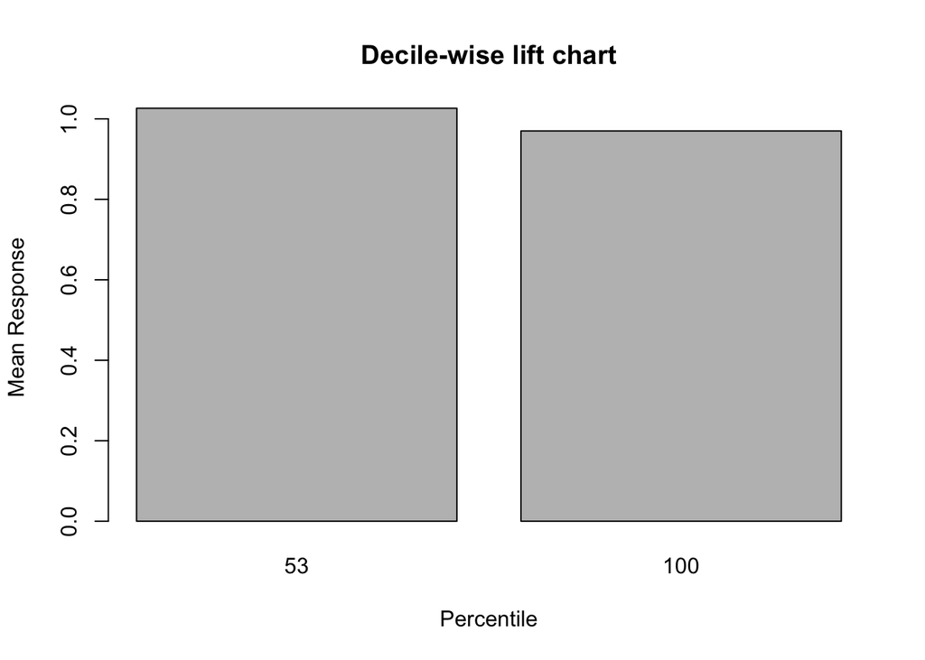

```r
barplot(gains_table$mean.resp / mean(dt_lift$actuals), names.arg = gains_table$depth, xlab = "Percentile",
        ylab = "Mean Response", main = "Decile-wise lift chart")
```

```r
predictions <- predict(model_dt, newdata = test_data, type = "raw")
actuals <- test_data$event_type_cart

dt_lift <- data.frame(predictions = as.numeric(predictions), actuals = as.numeric(actuals))

dt_lift <- dt_lift[order(-dt_lift$predictions), ]

gains_table <- gains(predicted = dt_lift$predictions, actual = dt_lift$actuals)
```

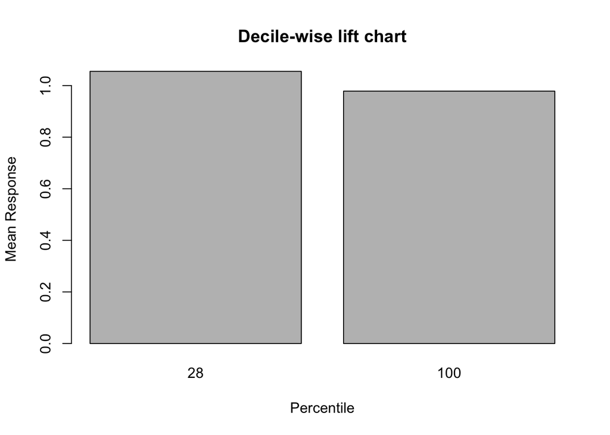

```r
barplot(gains_table$mean.resp / mean(dt_lift$actuals), names.arg = gains_table$depth, xlab = "Percentile",
        ylab = "Mean Response", main = "Decile-wise lift chart")
```

### Lift curve

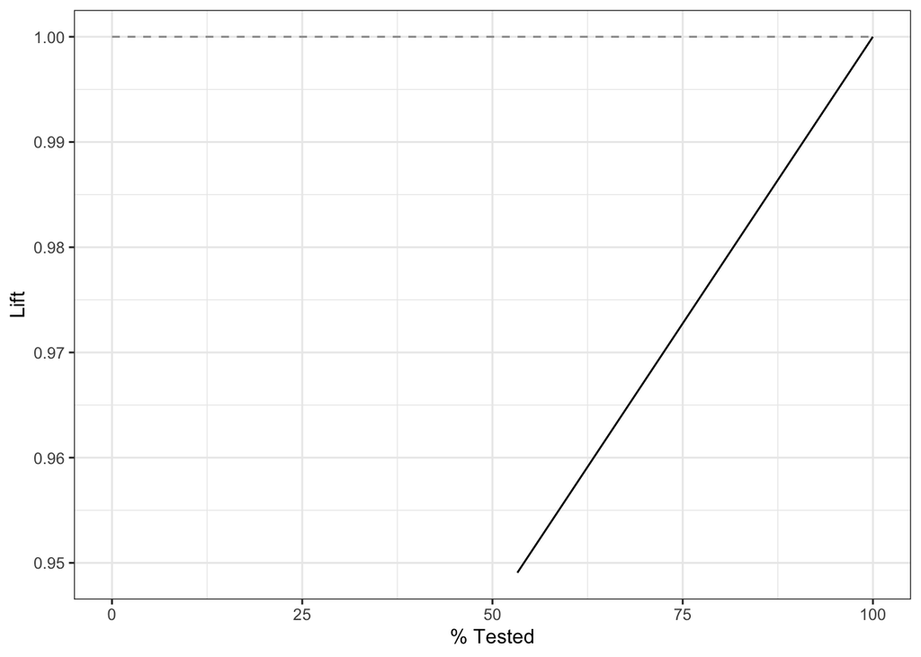

```r
predictions <- predict(model_glm, newdata = test_data)


lift_data <- data.frame(
  actuals = as.factor(test_data$event_type_cart),
  predictions = as.numeric(predictions)
)

lift_curve_glm <- yardstick::lift_curve(data = lift_data,actuals,predictions)

autoplot(lift_curve_glm, main = "Lift Curve")
```

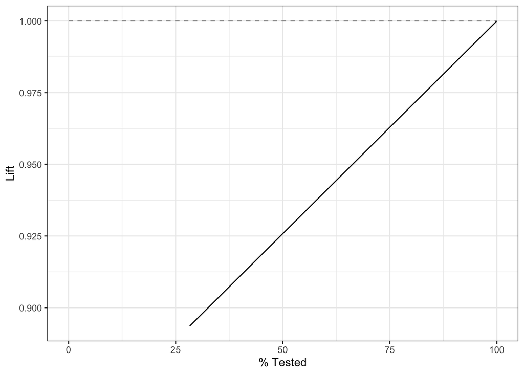

```r
predictions <- predict(model_dt, newdata = test_data)


lift_data <- data.frame(
  actuals = as.factor(test_data$event_type_cart),
  predictions = as.numeric(predictions)
)

lift_curve_dt <- yardstick::lift_curve(data = lift_data,actuals,predictions)

autoplot(lift_curve_dt, main = "Lift Curve")
```

Considerations: The lift curve helps you understand how well your model is performing compared to a baseline. Higher lift values indicate better performance.